# Day 3: Script writing and quality checking and control

# Objectives

1. Write and run scripts.
2. Download data using *wget* or/and *curl*
3. Describe reasons for quality checking in bacterial WGS data.
4. Inspect and interpret the quality of bacterial WGS data
5. Identify contamination (species)

# Day 2 recap

1. Create (by *cp*, *mkdir*), move (*mv*), copy (*cp*), and remove (*rm*).
2. Search (*grep* and options *-B* and *-A*) and redirect output (“>”, “>>”, “|”).
3. For loops (reduces typing mistakes, keywords: *for*, $, “{}”).
4. Get rid of repetitive name from files.

## Writing scripts

- Command line is powerful in that it can allow us to write scripts.
- This is done by saving commands in a file (called script) and running them together.
- Although it requires an additional time investment initially, scripts saves time since they can be run repeatedly.
- Thus they can also address the reproducibility challenge.
- Given sequencing reads, we would want to pull out bad reads and write them to a file to investigate them.
- As before, we investigate reads with long sequences of N’s but this time using a script (to use it each time).
- Let’s create a script and call it *bad-reads-script.sh*.
- Note, bad reads have a lot of Ns, $\therefore$, we will use grep.

```r
#. 1 login to ilifu
#. 2 Change the dir to your bacterial_wgs_bioinformatics
#. 3 Create a new dir named scripts and change into this dir
#. 4
nano bad-reads-script.sh
#. 5
grep -B1 -A2 -h NNNNNNNNNN *.fastq | grep -v '^--' > scripted_bad_reads.txt
#. 6
Ctl + o
# 7. Run the script
bash bad-reads-script.sh
# 8. Make the script to tell us we are done
nano bad-reads-script.sh
echo "Script finished"
Ctl + o
# 9. Run the script
bash bad-reads-script.sh
```

### Making the script into a program

- Bash is a computer program that we have been telling the computer to use.
- Let’s check the file permissions of the script we created. Is it executable? Use the **ls** command.
- Change the file to be executable.
- Run the script again using

```r
./bad-reads-script.sh
```

### Moving and downloading data

- Here we show some command to download data.
- Two programs are used to download data from a remote server to a local machine: *wget*, and *curl*.
- Although they were designed to do different tasks, different options are given to them to get the same behaviour.
- *wget* and *curl* are mostly interchangeable.
- *wget* - short for “world wide web get”.
- *wget* is useful for downloading web pages or data at a web address.
- *cURL* - should be read as “see URL”.
- *cURL*’s basic function is to display webpages or data at a web address.
- The choice on which one to use depends on the OS, most computers have one of the two.
- We are going to download a very small tab-delimited file from Ensembl.
- The file contains information on the data the Ensembl bacteria server.
- *which* scans through the system looking for everything installed, it tells the folder it is installed to.
- Check which of the two programs you have.
- If the program isn’t installed, it returns nothing.

```r
which curl
which wget

# Depends on the program installed
wget ftp://ftp.ensemblgenomes.org/pub/release-37/bacteria/species_EnsemblBacteria.txt
curl -O ftp://ftp.ensemblgenomes.org/pub/release-37/bacteria/species_EnsemblBacteria.txt
```

- For *wget*, to download, just use the command without any modifiers.
- For *curl*, *-O* tells *curl* to download that page and save the file using the same file name.
- Both *wget* and *curl* download to the computer the command line belong to (local or cluster/server).

## Data transfer (between local machine and cloud)

- Sometimes we may need to upload data to the server or download from the server (results).
- Several ways can be used, but it’s easier to start transfer locally.
- That is, to be typing from a local machine (not on server).
- $\therefore$ transfer programs should be installed on our local computer.
- One can use *scp* to copy data to/from a virtual machine from a Linux, Mac OS, or Windows (with Git Bash) local machine.
- *scp* - stands for secure *cp* (copy).
- Thus, in place of *cp* we can use *scp*.
- Similarly to the *cp* the synthax is *scp source destination*.

```r
# locally
scp pathtofile-source pathtofile-destination
# From local to server (ilifu in our case). use login credentials
scp pathtofile-locally username@transfer.ilifu.ac.za:pathtofile-destination
# From server to local
scp username@transfer.ilifu.ac.za:pathtofile-source pathtofile-destination
# Folder transfer
scp -r pathtofile-source pathtofile-destination
```

## Running programs on the server/cloud

- There programs that are globally installed, these are shown by

```r
# Check available softwares/tools
module available
# Add these to your environment
module load modulename
```

# Bioinformatics pipeline for bacterial WGS

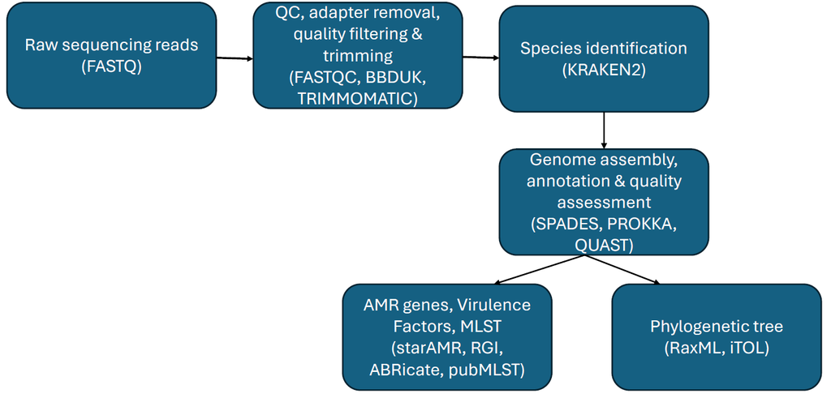

## Why checking the quality of WGS data

We check the quality of WGS data for the following reasons

1. Read Quality:
- Base Quality Scores: helps to identify poor-quality reads that may need to be trimmed or discarded.
- Adapter Contamination - to detect and remove adapter sequences to prevent misalignment and incorrect variant calling (not applicable).
2. Contamination:
- Foreign DNA - to identify contamination from other organisms’ DNA ensures that the sequence data accurately represents the target organism.
- Cross-Sample Contamination - to ensure no cross-sample contamination helps maintain the integrity of individual sample analyses.
3. Biases and Artifacts:
- GC Bias - to detect and correct for GC content biases (achieve uniform coverage across the genome).
- PCR Duplicates - to identify and remove PCR duplicates reducing biases and ensure that reads are unique and representative.
4. Resource Efficiency:
- Save on computational resources - High-quality data reduces the need for extensive computational resources to handle large amounts of low-quality data.
- Early identification and correction of quality issues saves time and Cost associated with re-sequencing or extensive data cleaning.
5. Reproducibility:
- Ensures reproducibility and comparability of results across studies and sequencing platforms, guaranteeing reliable results.
- Enhances credibility of the research by meeting scientific journals’ publication standards.

## Common Quality Control Steps

### Inspect read quality

- Assess an overview of read quality use quality scores, GC content, and other metrics (FASTQC, MULTIQC).
- Trimming and Filtering - removing adapters and low quality bases (BBDUK or/and TRIMMOMATIC, CUTADAPT).

### Identify contaminants

- Check for contaminants (identify species) - use KRAKEN2 or DECONTAM to identify and filter out contaminant sequences.

### Mark and remove PCR duplicates

- After noting high duplication levels we remove them by PICARD or SAMTOOLS.

### Coverage Analysis:

- Assess genome coverage and identify regions with insufficient coverage (BEDTools or QualiMap).

Overall, high-quality whole genome sequencing data helps researchers - To trust that their analyses are based on accurate, reliable, and complete genomic information, - Leads to more robust scientific conclusions.

## Requesting for computing resources

- When analyzing the bacterial genomes we require computer resources including storage and also computer time.
- On a high performance computing platform these needs to be requested.
- This is done in two ways
  - Requesting resources interactively
  - Or through a submission script
- SLURM (Simple Linux Utility for Resource Management).
- An open-source job scheduler used in HPC environments to manage and allocate resources among various computing tasks.
- SLURM manages resources such as CPUs, memory, and GPUs on a cluster, ensuring that jobs are allocated resources efficiently.
- It schedules jobs based on priorities, dependencies, and resource requirements, optimizing the use of available resources.
- It is highly scalable and is used in some of the world’s largest supercomputers.
- It supports various job types, including batch, interactive, and parallel jobs.
- It offers features like job arrays and reservations.
- It provides a range of commands (e.g., sbatch, srun, squeue, scancel) for job submission, monitoring, and management.
- Alternatives to SLURM are
  1. Portable Batch System (PBS)
     1. Torque - An open-source variant of PBS that integrates with the Moab workload manager.
     2. PBS Pro - Is the commercial version of PBS, offering advanced features and support.
  2. Grid Engine:
     1. Oracle Grid Engine: Originally known as Sun Grid Engine (SGE), used for job scheduling in grid computing environments.
     2. Open Grid Scheduler: An open-source fork of Grid Engine.
  3. LSF (Load Sharing Facility):
     - Developed by IBM.
     - LSF is a commercial job scheduler.
     - It provides robust job scheduling, resource management, and workload balancing features.

Our HPC environment is based on the SLURM.

## Running FASTQC and MULTIQC: ilifu

We first run FASTQC and MULTIQC using the modules on ilifu and then run the nextflow pipeline for quality checking and trimming

```r
# Requesting resources interactively
srun --nodes=1 --reservation=cbio-training3 --mem=8g --time 8:00:00 --job-name "032" --pty /bin/bash

## Quality checking of raw reads
module avail
module load fastqc/0.11.9
module load  multiqc/1.22.3

## Run fastqc
# Make a directory in your home
mkdir bacterial_wgs_training
# Change dir to bacterial_wgs_training
cd bacterial_wgs_training
## Check the help of the tool
fastqc --help
# create output folder for FASTQC results
mkdir rawfastqc

# Run FASTQC
fastqc  /cbio/training/courses/2024/bacterial_wgs/data/data/* -o rawfastqc/

## Amalgamate results
# check help for multiqc
multiqc --help | less
## Run multiqc
multiqc rawfastqc/ -o rawfastqc/
```

## Exercise

1. Delete the rawfastqc dir

Running the same using a script

```r
# Make a dir to save scripts
mkdir scripts
# Also make dir to store logs in /users/username/bacterial_wgs_training
mkdir logs
## change to your script dir
cd scripts

nano fastqc.sh
```

```r
#!/bin/bash
#SBATCH --job-name='fastqc'
#SBATCH --nodes=1
#SBATCH --partition=Main
#SBATCH --mem=8GB
#SBATCH --output=/users/username/bacterial_wgs_training/logs/fastqc-stdout.txt
#SBATCH --error=/users/username/bacterial_wgs_training/logs/fastqc-stderr.txt
#SBATCH --time=2:00:00
#SBATCH --mail-user=useremail
#SBATCH --mail-type=FAIL

# load required modules
module load fastqc/0.11.9
module load  multiqc/1.22.3

# create output folder for FASTQC results
mkdir rawfastqc

# Run FASTQC (absolute and relative path)
fastqc  /cbio/training/courses/2024/bacterial_wgs/data/data/* -o rawfastqc/

## Amalgamate results Run multiqc
multiqc rawfastqc/ -o rawfastqc/
```

## What is nextflow?

- If there are several samples it might take time to assess the quality thus we use workflow management system that enables the orchestration of bioinformatics pipelines.
- This include nextflow and snakemake.
- In this training, we will use nextflow.
- Key features of nextflow:
  - Uses a Groovy-based DSL to define workflows, making it flexible and powerful for complex pipeline creation.
  - It facilitates parallel execution of tasks, optimizing the use of computational resources.
  - It ensures reproducibility by managing dependencies through Docker or Singularity containers, and by tracking software versions.
  - Workflows can run on various platforms (portable), including local servers, cloud environments (e.g., AWS, Google Cloud), and HPC clusters.
  - It uses a dataflow programming model, allowing workflows to be designed based on the flow of data.
  - It can scale from a single machine to large clusters and cloud-based environments.
  - There is a rich ecosystem of pre-built pipelines and a vibrant community providing support and sharing resources.

## Running fastq_QC nextflow pipeline

- Check if there is a nextflow pipeline
- Git clone https://github.com/kviljoen/fastq_QC
- Things to check configuration files, nextflow parameters, main.nf

```r
#!/bin/bash
#SBATCH --job-name='fastq_QC'
#SBATCH --nodes=1
#SBATCH --partition=Main
#SBATCH --mem=8GB
#SBATCH --output=/users/username/bacterial_wgs_training/logs/fast_QC-nf-stdout.txt
#SBATCH --error=/users/username/bacterial_wgs_training/logs/fastq_QC-nf-stderr.txt
#SBATCH --time=12:00:00
#SBATCH --mail-user=usernameemail
#SBATCH --mail-type=FAIL


echo "ISOLATES QUALITY CHECKING, FILTERING AND TRIMMING (RAW QC, BBDUK & POST QC"

# Set important dirs
proj="/users/username/bacterial_wgs_training/"

# For nextflow DSL1 pipeline
module load nextflow/22.10.7

cd ${proj}
nextflow run ${proj}fastq_QC --reads '/cbio/training/courses/2024/bacterial_wgs/data/data/*_R{1,2}_001.fastq.gz' \
        -profile ilifu -resume --email "email" --outdir ${proj}'quality_checking'
```

# Species Identification

## Why is it neccessary?

1. Clinical Diagnosis and Treatment - Accurate diagnosis, antibiotic selection, preventing resistance.
2. Public Health and Epidemiology - Outbreak investigation, surveillance.
3. Food Safety - Identify contamination source and to comply to regulations.
4. Environmental Monitoring and Biotechnology - Identify pollution indicators, specific bacteria can be used in bioremediation to clean up environmental pollutants and for optimizing processes such as fermentation, waste treatment, and enzyme production.
5. Scientific Research - to understanding the composition of microbial communities in various environments (e.g., human gut, soil, water), studying species roles and interactions within ecosystems, contributing to a better understanding of microbial ecology.
6. Antimicrobial Resistance (AMR) - determining species resistance patterns, which is critical for developing strategies to combat AMR, aid surveillance programs aimed at monitoring and controlling the spread of AMR.

## Techniques for Bacterial Identification

- Morphological and Biochemical Tests -Traditional methods include Gram staining, colony morphology, and biochemical assays.
- Molecular Techniques - Modern techniques include DNA sequencing, PCR, and mass spectrometry (e.g., MALDI-TOF). These methods provide higher accuracy and speed in identifying bacterial species.
- Next-Generation Sequencing (NGS) - Metagenomics and whole-genome sequencing offer comprehensive insights into bacterial communities and their functions.